# Visión por Computador

### Transformacións Proxectivas: escena 3D -> imaxe 2D

A continuación veremos as diferentes transformacións de coordenadas para pasar de coordenadas 3D nun sistema de referencia do mundo ata chegar as coordenadas imaxe de puntos sobre obxectos da escena. Consideraremos un exemplo sintético simple, puntos nos vértices dun cubo 3D, para ilustrar o proceso.

**Empezamos co código que representa un cubo nun sistema de referencia externo (mundo, e o sistema de coordenadas unha cámara ubicada nesa escena**

- T: representa a traslación da orixe sistema de coordenadas da cámara respecto do sistema de coordenadas do muno.
- R: representaa matriz de rotación en 3D do sistema de coordenadas da cámara con respecto ao sistema de coordenadas do mundo.
- P: Representa a matriz de transformación completa para coordenadas homoxéneas.

```
Dimensions of p_tilde: (8, 4, 1)
R_x=
 [[ 1.  0.  0.]
 [ 0.  1. -0.]
 [ 0.  0.  1.]]
R_y=
 [[ 1.  0. -0.]
 [ 0.  1.  0.]
 [ 0.  0.  1.]]
R_z=
 [[ 0.93969262 -0.34202014  0.        ]
 [ 0.34202014  0.93969262  0.        ]
 [ 0.          0.          1.        ]]
R=
 [[ 0.93969262 -0.34202014  0.        ]
 [ 0.34202014  0.93969262  0.        ]
 [ 0.          0.          1.        ]]
T=
 [  2   2 -10]
P=
 [[ 0.93969262 -0.34202014  0.         -2.        ]
 [ 0.34202014  0.93969262  0.         -2.        ]
 [ 0.          0.          1.         10.        ]
 [ 0.          0.          0.          1.        ]]
```

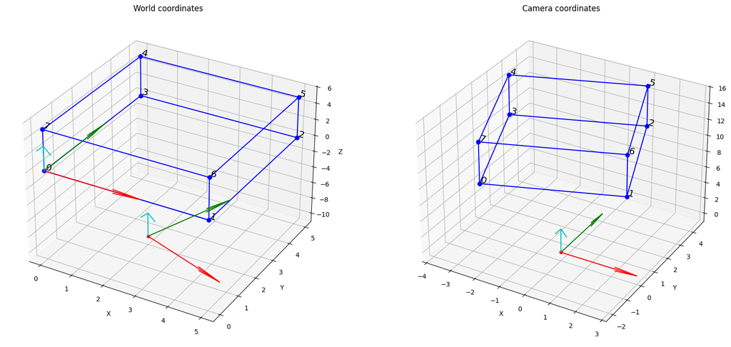

```python
import numpy as np
import matplotlib.pyplot as plt

#-------------------------Some support functions------------------------------------
def rotation_euler (theta_x, theta_y, theta_z) :
# a function that returns a 3 by 3 rotation matrix given the Euler rotation angles in radians.
    R_x = np.array([[1, 0, 0], [0, np.cos(theta_x), -np.sin(theta_x)], [0, np.sin(theta_x), np.cos(theta_x)]])
    R_y = np.array([[np.cos(theta_y), 0, -np.sin(theta_y)], [0, 1, 0], [np.sin(theta_y), 0, np.cos(theta_y)]])
    R_z = np.array([[np.cos(theta_z), -np.sin(theta_z), 0], [np.sin(theta_z), np.cos(theta_z), 0], [0, 0, 1]])

    print('R_x=\n', R_x, '\nR_y=\n', R_y, '\nR_z=\n', R_z)
    return(R_x @ R_y @ R_z)

def plot_cube (axis, p_t) :
# Given 8 vertices (p_t is 8 by 4 by 1), plot the 3D cube edges and vertices
    axis.plot3D(p_t[:,0,0], p_t[:,1,0], p_t[:,2,0], c='b', marker='o')
    axis.plot3D([p_t[0,0,0], p_t[7,0,0]], [p_t[0,1,0], p_t[7,1,0]], [p_t[0,2,0], p_t[7,2,0]], c='b', marker='o')
    axis.plot3D([p_t[2,0,0], p_t[5,0,0]], [p_t[2,1,0], p_t[5,1,0]], [p_t[2,2,0], p_t[5,2,0]], c='b', marker='o')
    axis.plot3D([p_t[1,0,0], p_t[6,0,0]], [p_t[1,1,0], p_t[6,1,0]], [p_t[1,2,0], p_t[6,2,0]], c='b', marker='o')
    axis.plot3D([p_t[0,0,0], p_t[3,0,0]], [p_t[0,1,0], p_t[3,1,0]], [p_t[0,2,0], p_t[3,2,0]], c='b', marker='o')
    axis.plot3D([p_t[4,0,0], p_t[7,0,0]], [p_t[4,1,0], p_t[7,1,0]], [p_t[4,2,0], p_t[7,2,0]], c='b', marker='o')
    axis.set_xlabel('X')
    axis.set_ylabel('Y')
    axis.set_zlabel('Z')
    axis.axis('equal')
    for i in range(8):
        axis.text(p_t[i,0,0], p_t[i,1,0], p_t[i,2,0], '{}'.format(i), 'x',fontsize='x-large')

def plot_camera (axis, c_t) :
    axis.scatter(c_t[0], c_t[1],c_t[2], c='r', marker='o')
#---------------------------------------------------------------

# Generate 8 vertices of a 5 by 5 by 5 sized cube with one of the vertices at origin of the world coordinates (homogenous)
N = 8
p_tilde = np.array([[0, 0, 0, 1],
                    [5, 0, 0, 1],
                    [5, 5, 0, 1],
                    [0, 5, 0, 1],
                    [0, 5, 5, 1],
                    [5, 5, 5, 1],
                    [5, 0, 5, 1],
                    [0, 0, 5, 1]])

p_tilde = np.expand_dims(p_tilde, 2) # the dimension for p_tilde will change from (N by 4) to (N by 4 by 1)
print('Dimensions of p_tilde:', p_tilde.shape)
#---------------------------------------------------------------

T = np.array([2,2,-10])
# plot the cube, with respect to the world coordinates
fig = plt.figure(figsize=(20,10))
ax = fig.add_subplot(1,2,1, projection='3d')
plot_camera(ax,T)
ax.quiver(0,0,0,1,0,0, color='r', length=3,arrow_length_ratio=0.3)
ax.quiver(0,0,0,0,1,0, color='g', length=3,arrow_length_ratio=0.3)
ax.quiver(0,0,0,0,0,1, color='c', length=3,arrow_length_ratio=0.3)

plot_cube (ax, p_tilde)
ax.set_title('World coordinates')
#ax.view_init(azim=0, elev=0, roll=0)
#------------------------------------------------------------

# Setup the camera rotation and translation with respect to the world coordinates
R = rotation_euler(0*20*np.pi/180, 0*30*np.pi/180, 1*20*np.pi/180)

P = np.eye(4)
P[0:3,0:3] = R
P[0:3,3] = -T
print('R=\n', R, '\nT=\n', T, '\nP=\n', P)


#---------------------------------------------------------------
# Transform the 3D coordinates from world to camera coordinates
p_c_tilde = P @ p_tilde  # @ is matrix multiply in python

# P is 4 by 4 and p_tilde is 8 by 4 by 1, so this is not a standard matrix multiply!
# It is using a feature called broadcasting. It will effectively multiple each
# of the 4 by 1 homogeneous point representations by the 4 by 4 matrix to
# result in a 8 by 4 by 1 output.

'''
NUMPY BROADCASTING -- very important feature

https://www.tutorialspoint.com/numpy/numpy_broadcasting.htm

https://numpy.org/devdocs/user/basics.broadcasting.html
'''

#---------------------------------------------------------------


# plot the points in camera coordinates
ax1 = fig.add_subplot(1,2,2, projection='3d')
plot_camera(ax1,[0,0,0])

X=[1,0,0]@R
Y=[0,1,0]@R
Z=[0,0,1]@R

ax.quiver(T[0],T[1],T[2],X[0],X[1],X[2], color='r', length=3, arrow_length_ratio=0.3)
ax.quiver(T[0],T[1],T[2],Y[0],Y[1],Y[2], color='g', length=3, arrow_length_ratio=0.3)
ax.quiver(T[0],T[1],T[2],Z[0],Z[1],Z[2], color='c', length=3, arrow_length_ratio=0.3)

ax1.quiver(0,0,0,1,0,0, color='r', length=3,arrow_length_ratio=0.3)
ax1.quiver(0,0,0,0,1,0, color='g', length=3,arrow_length_ratio=0.3)
ax1.quiver(0,0,0,0,0,1, color='c', length=3,arrow_length_ratio=0.3)


plot_cube (ax1, p_c_tilde)
ax1.set_title('Camera coordinates')
plot_camera(ax1,[0,0,0])
```

**Código: Proxección da cámara estenopeica (pin-hole): de coordenadas 3D no sistema da cámara ao plano imaxe 2D**

Consideramos agora a matriz de proxección da cámara como función da distancia focal.

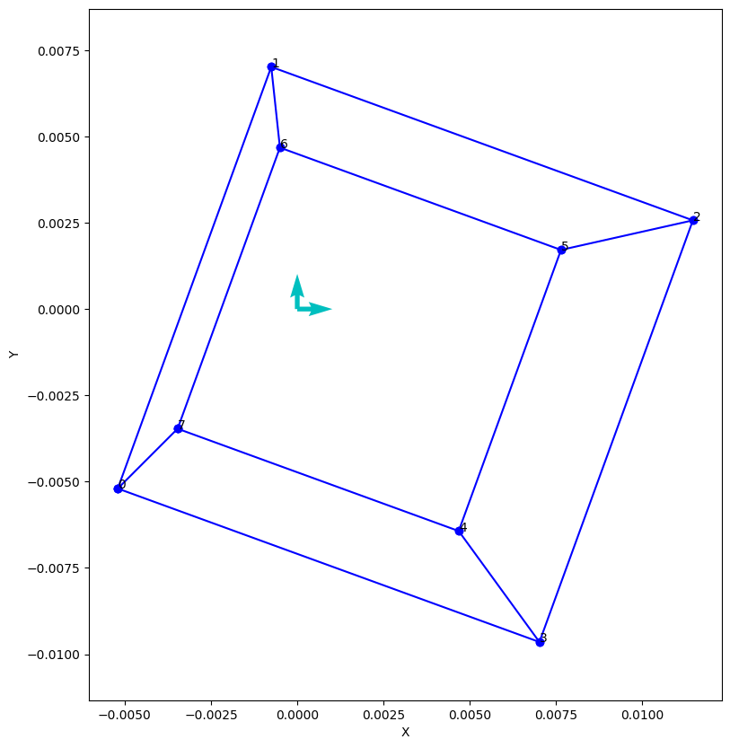

```python
#---------Utility function to draw the sides of a cube in 2 dimensions
def plot_cube_2D (axis, y, x) :
# Given 8 vertices (p_t is 8 by 4 by 1), plot the 3D cube edges and vertices
    axis.plot(y, x, c='b', marker='o')
    axis.plot([y[0], y[7]], [x[0], x[7]], c='b', marker='o')
    axis.plot([y[2], y[5]], [x[2], x[5]], c='b', marker='o')
    axis.plot([y[1], y[6]], [x[1], x[6]], c='b', marker='o')
    axis.plot([y[0], y[3]], [x[0], x[3]], c='b', marker='o')
    axis.plot([y[4], y[7]], [x[4], x[7]], c='b', marker='o')

    axis.set_xlabel('X')
    axis.set_ylabel('Y')
    axis.axis('equal')
    for i in range(8):
        axis.text(y[i], x[i], '{}'.format(i))


#--------------------------------------------

'''Perspective projection'''
f = 0.026  # in meters -- iphone 11 camera focal length = 26 mm
x = np.array([[f, 0, 0, 0], [0, f, 0, 0], [0, 0, 1, 0]]) @ p_c_tilde
x_c = x[:,0]/x[:,2]
y_c = x[:,1]/x[:,2]

fig = plt.figure(figsize=(20,10))
ax = fig.add_subplot(1,2,1)
ax.quiver([0,0],[0,0],[1,0,], [0,1], color='c')
plot_cube_2D (ax, y_c, x_c)
#View from below the cube
```

**Código: de coordenadas no plano imaxe 2D a coordenadas pixel**

Engádese agora o efecto do factor de escala asociado ao tamaño de píxel, e o cambio de orientación e orixe das coordenadas píxel.

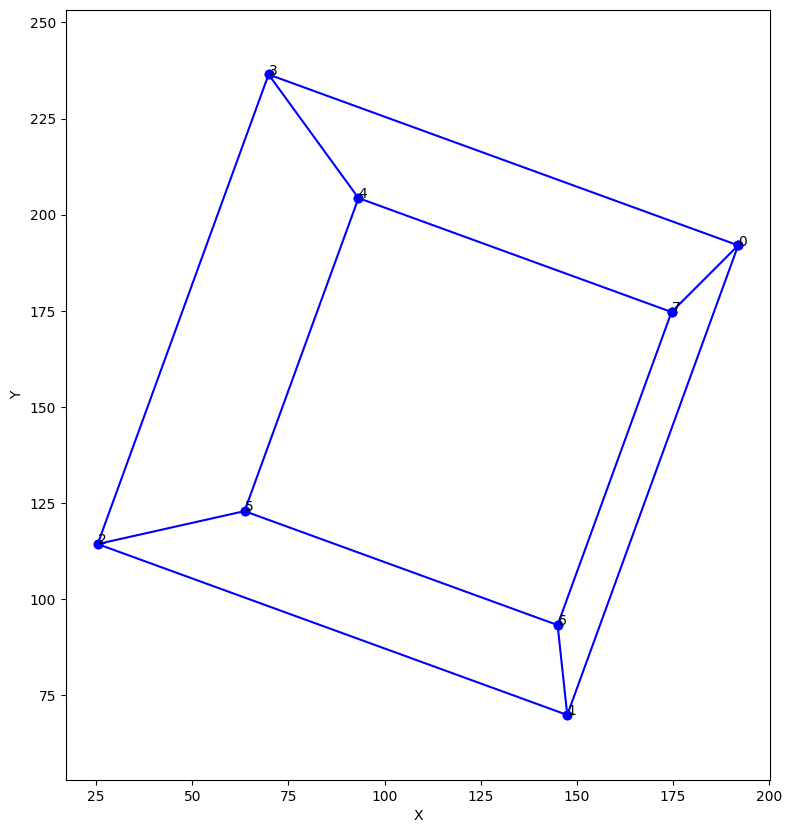

```python
c_x = 140
c_y = 140
s_x = 1.0e-4  # 1.22 microns https://www.ephotozine.com/article/complete-guide-to-image-sensor-pixel-size-29652
s_y = 1.0e-4   # 1.22 microns
x_s = -x_c/s_x + c_x
y_s = -y_c/s_y + c_y


fig = plt.figure(figsize=(20,10))
ax1 = fig.add_subplot(1,2,2)
plot_cube_2D (ax1, y_s, x_s)
#ax1.set_xlim(0,2*c_x)
#ax1.set_ylim(2*c_y,0)
```

Mapear coordenadas de puntos 3D a píxeles 2D é unha tarefa común na visión por computador. Este proceso implica proxectar coordenadas 3D de puntos da escena nos píxeles correspondentes na imaxe 2D. Para realizar este mapeo necesitamos coñecer:

- Os parámetros intrínsecos da cámara (distancia focal, tamaño do píxel en mm, o centro do plano imaxe en píxeles, parámetros de distorsión) e
- Os parámetros extrínsecos (rotación e translación entre o sistema de coordenadas mundo 3D e o sistema de coordenadas 3D asociado á cámara).

A función OpenCV **cv2.projectPoints(points_3d, rvec, tvec, camera_matrix, dist_coeffs)** permite realizar os cálculos necesarios,

onde,

- points_3d – Puntos 3D no sistema de coordenadas mundo.
- rvec – Vector de rotación
- tvec – Vector de translación
- camera_matrix – Parámetros físicos da cámara.
- dist_coeffs: Vector de coeficientes de distorsión.

Considera as esquinas dun cubo 3D, represéntaas xunto coas arestas en 3D e, a continuación, calcula as proxeccións das esquinas no plano da imaxe da cámara. Mostra exemplos para diferentes conxuntos de intrínsecas e extrínsecas.

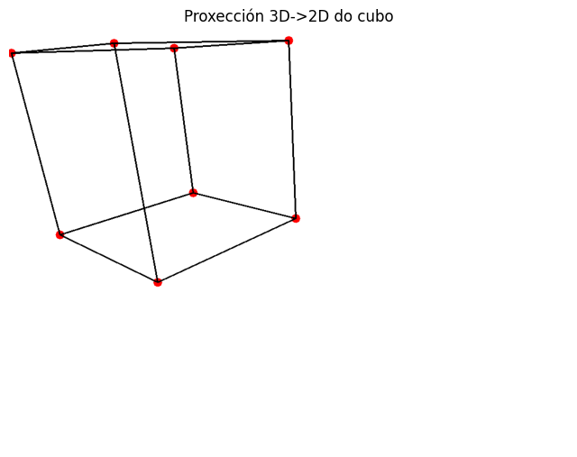

```python
# Definir as esquinas dun cubo
cubo = 50
puntos_cubo = np.array([
    [0, 0, 0],
    [cubo, 0, 0],
    [cubo, cubo, 0],
    [0, cubo, 0],
    [0, 0, -cubo],
    [cubo, 0, -cubo],
    [cubo, cubo, -cubo],
    [0, cubo, -cubo]
], dtype=np.float32)

# Parâmetros intrínsecos
distancia_focal = 800
centro = (320, 240)
matrix = np.array([
    [distancia_focal, 0, centro[0]],
    [0, distancia_focal, centro[1]],
    [0, 0, 1]
], dtype=np.float64) # Matriz intrínseca da cámara
coef = np.zeros(5)  # Coeficiente de distorsión

# Parâmetros extrínsecos da cámara
rotacion = np.array([0.4, 0.7, 0.1])  # vector de rotación
translacion = np.array([30, -10, -100], dtype=np.float32).reshape(3, 1) # vector de translación

# Proxectar puntos 3D a 2D
puntos_img, _ = cv2.projectPoints(puntos_cubo, rotacion, translacion, matrix, coef) # puntos da imaxe
puntos_img = puntos_img.squeeze()

# Imprimimos o cubo proxectado
img_vis = np.ones((height, width, 3), dtype=np.uint8) * 255
for pt in puntos_img:
    cv2.circle(img_vis, (int(pt[0]), int(pt[1])), 8, (255,0,0), -1)

# Debuxar arestas do cubo
edges = [
    (0,1), (1,2), (2,3), (3,0),
    (4,5), (5,6), (6,7), (7,4),
    (0,4), (1,5), (2,6), (3,7)
]
for i,j in edges:
    cv2.line(img_vis, tuple(puntos_img[i].astype(int)), tuple(puntos_img[j].astype(int)), (0,0,0), 2)

plt.figure(figsize=(8,8))
plt.imshow(img_vis)
plt.title("Proxección 3D->2D do cubo")
plt.axis('off')
plt.show()
```

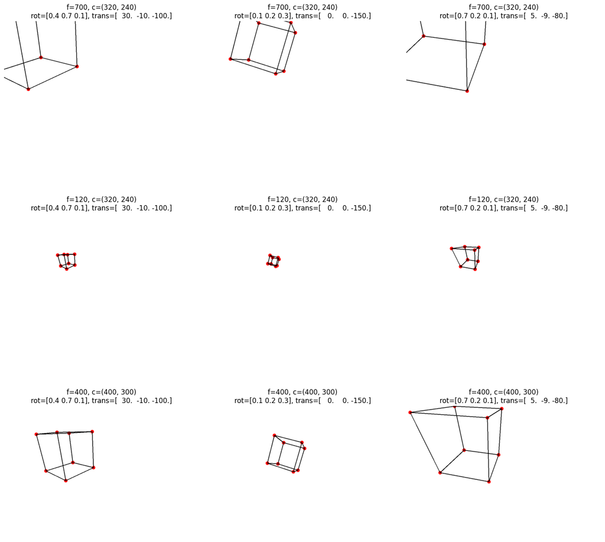

```python
# Exemplos para diferentes conxuntos de intrínsecas e extrínsecas

# Diferentes parámetros intrínsecos e extrínsecos
intrinsecos = [
    {"focal": 700, "centro": (320, 240)},
    {"focal": 120, "centro": (320, 240)},
    {"focal": 400, "centro": (400, 300)}
]
extrinsecos = [
    {"rot": np.array([0.4, 0.7, 0.1]), "trans": np.array([30, -10, -100], dtype=np.float32).reshape(3, 1)},
    {"rot": np.array([0.1, 0.2, 0.3]), "trans": np.array([0, 0, -150], dtype=np.float32).reshape(3, 1)},
    {"rot": np.array([0.7, 0.2, 0.1]), "trans": np.array([5, -9, -80], dtype=np.float32).reshape(3, 1)}
]

fig, axs = plt.subplots(3, 3, figsize=(15, 15))

height, width = 600, 886

for i, intr in enumerate(intrinsecos):
    matrix = np.array([
        [intr["focal"], 0, intr["centro"][0]],
        [0, intr["focal"], intr["centro"][1]],
        [0, 0, 1]
    ], dtype=np.float64)

    coef = np.zeros(5)

    for j, extr in enumerate(extrinsecos):

        puntos_img, _ = cv2.projectPoints(
            puntos_cubo, extr["rot"], extr["trans"], matrix, coef
        )
        puntos_img = puntos_img.squeeze()

        img_vis = np.ones((height, width, 3), dtype=np.uint8) * 255
        for pt in puntos_img:
            cv2.circle(img_vis, (int(pt[0]), int(pt[1])), 8, (255,0,0), -1)
        edges = [
            (0,1), (1,2), (2,3), (3,0),
            (4,5), (5,6), (6,7), (7,4),
            (0,4), (1,5), (2,6), (3,7)
        ]
        for a,b in edges:
            cv2.line(img_vis, tuple(puntos_img[a].astype(int)), tuple(puntos_img[b].astype(int)), (0,0,0), 2)
        axs[i, j].imshow(img_vis)
        axs[i, j].set_title(f"f={intr['focal']}, c={intr['centro']}\nrot={extr['rot']}, trans={extr['trans'].ravel()}")
        axs[i, j].axis('off')
plt.tight_layout()
plt.show()
```

## Calibración de cámaras

Para calibrar unha cámara necesitamos fixar a correspondencia entre coordenadas de puntos da escena con coordenadas píxel na imaxe capturada.

Para facer o proceso doado,emprégase habitualmente unha superficie rectangular plana que contén a imaxe dun taboleiro de xadrez. Coñecidos os tamaños do taboleiro e dos cadrados é doado identificar as esquinas na imaxe e establecer correspondencias. A partires dun conxunto de correspondencias para un conxunto de imaxes tomadas con diferentes puntos de vista e posible obter un sistema de ecuacións a partires do cal determinas os parámetros intrínsecos da cámara e a distorsión provocada pola lente.

O código orixinal pode obterse na seguintene ligazón dun tutorial de OpenCV:

https://github.com/opencv/opencv/blob/master/samples/python/calibrate.py

Podedes descargar un plano de calibración de referencia para imprimir dende aquí:

https://www.me.psu.edu/brennan/ME545/2012/FinalProjects/Mangus_3DCameraCalibration/Calibration_Images.html

Para calibrar a vosa propia cámara teríades que imprimir esa imaxe e tomar fotos dende varios puntos de vista. Empezaremos usando unhas imaxes xa captadas e veremos como obter os parámetros de calibración

```python
import numpy as np
import cv2
from glob import glob
import matplotlib.pyplot as plt
# to run in google colab
#import sys

square_size = 2.88

img_mask = calib_images_path+'/IMG*.jpg'

#Hai que indicar o número de esquinas interiores por fila e columna (número de cadrados menos 1)
pattern_size = (7,9)

figsize = (20, 20)
```

```python
img_names = glob(img_mask)
num_images = len(img_names)
print(num_images)

pattern_points = np.zeros((np.prod(pattern_size), 3), np.float32)
pattern_points[:, :2] = np.indices(pattern_size).T.reshape(-1, 2)
pattern_points *= square_size

obj_points = []
img_points = []
h, w = cv2.imread(img_names[0]).shape[:2]
```

```
4
```

## Paso 1: atopar todas as esquinas no plano de calibración

```
processing ./Images/Calibration_images/IMG_1080.jpg...
chessboard not found
processing ./Images/Calibration_images/IMG_1077.jpg...
./Images/Calibration_images/IMG_1077.jpg... OK
processing ./Images/Calibration_images/IMG_1074.jpg...
./Images/Calibration_images/IMG_1074.jpg... OK
processing ./Images/Calibration_images/IMG_1078.jpg...
./Images/Calibration_images/IMG_1078.jpg... OK
```

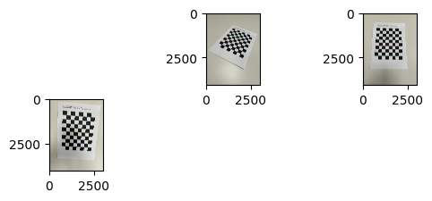

```
Removed images: ['./Images/Calibration_images/IMG_1080.jpg']
```

```python
#plt.figure(figsize=figsize)
del_imgs=[]

for i, fn in enumerate(img_names):
    print("processing %s... " % fn)
    imgBGR = cv2.imread(fn)

    if imgBGR is None:
        print("Failed to load", fn)
        del_imgs.append(fn)
        continue

    imgRGB = cv2.cvtColor(imgBGR, cv2.COLOR_BGR2RGB)
    img = cv2.cvtColor(imgRGB, cv2.COLOR_RGB2GRAY)

    assert w == img.shape[1] and h == img.shape[0], f"size: {img.shape[1]} x {img.shape[0]}"
    found, corners = cv2.findChessboardCorners(img, pattern_size)
    # # if you want to better improve the accuracy... cv2.findChessboardCorners already uses cv2.cornerSubPix
    # if found:
    #     term = (cv2.TERM_CRITERIA_EPS + cv2.TERM_CRITERIA_COUNT, 30, 0.1)
    #     cv2.cornerSubPix(img, corners, (5, 5), (-1, -1), term)

    if not found:
        print("chessboard not found")
        del_imgs.append(fn)
        continue

    if i < 12:
        img_w_corners = cv2.drawChessboardCorners(imgRGB, pattern_size, corners, found)
        plt.subplot(4, 3, i + 1)
        plt.imshow(img_w_corners)

    print(f"{fn}... OK")
    img_points.append(corners.reshape(-1, 2))
    obj_points.append(pattern_points)


plt.show()
print('Removed images: {}'.format(del_imgs))
for i, im in enumerate(del_imgs):
    img_names.remove(im)
#print(img_names)
```

## Paso 2: obter os coeficientes intrínsecos da cámara + os coeficientes de distorsión

obter tamén vectores de rotación e translación extrínsecos por imaxe. O vector de rotación é outra representación para unha matriz R completa

https://en.wikipedia.org/wiki/Rodrigues%27_rotation_formula

```python
# calculate camera distortion
rms, camera_matrix, dist_coefs, _rvecs, _tvecs = cv2.calibrateCamera(obj_points, img_points, (w, h), None, None)

print("\nRMS:", rms)
print("camera matrix:\n", camera_matrix)
print("distortion coefficients: ", dist_coefs.ravel())
```

```
RMS: 1.7756428013452166
camera matrix:
 [[3.00447908e+03 0.00000000e+00 1.50011617e+03]
 [0.00000000e+00 3.00625859e+03 2.05581894e+03]
 [0.00000000e+00 0.00000000e+00 1.00000000e+00]]
distortion coefficients:  [ 0.20746472 -0.66585616  0.0066288  -0.00565352 -0.18625366]
```

# Crea imaxes sen distorsións

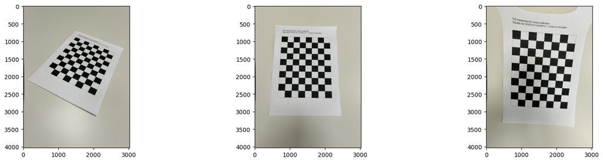

```
Done
```

```python
# undistort the image with the calibration
plt.figure(figsize=figsize)
for i, fn in enumerate(img_names):

    imgBGR = cv2.imread(fn)
    imgRGB = cv2.cvtColor(imgBGR, cv2.COLOR_BGR2RGB)

    dst = cv2.undistort(imgRGB, camera_matrix, dist_coefs)

    if i < 12:
        plt.subplot(4, 3, i + 1)
        plt.imshow(dst)

plt.show()
print("Done")
```

## Exemplo de proxección completa de 3D a 2D dun cubo

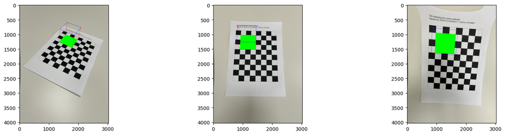

```python
objectPoints = (
    3
    * square_size
    * np.array([[0, 0, 0], [0, 1, 0], [1, 1, 0], [1, 0, 0], [0, 0, -1], [0, 1, -1], [1, 1, -1], [1, 0, -1]])
)


def draw(img, imgpts):
    imgpts = np.int32(imgpts).reshape(-1, 2)

    # draw ground floor in green
    img = cv2.drawContours(img, [imgpts[:4]], -1, (0, 255, 0), -1)

    # draw pillars in blue color
    for i, j in zip(range(4), range(4, 8)):
        img = cv2.line(img, tuple(imgpts[i]), tuple(imgpts[j]), (255), 3)

    # draw top layer in red color
    img = cv2.drawContours(img, [imgpts[4:]], -1, (0, 0, 255), 3)

    return img


plt.figure(figsize=figsize)
for i, fn in enumerate(img_names):

    imgBGR = cv2.imread(fn)
    imgRGB = cv2.cvtColor(imgBGR, cv2.COLOR_BGR2RGB)

    dst = cv2.undistort(imgRGB, camera_matrix, dist_coefs)

    imgpts = cv2.projectPoints(objectPoints, _rvecs[i], _tvecs[i], camera_matrix, dist_coefs)[0]
    drawn_image = draw(dst, imgpts)

    if i < 12:
        plt.subplot(4, 3, i + 1)
        plt.imshow(drawn_image)

plt.show()
```

Obter agora a matriz de calibración da vosa propia cámara.

```python
square_size = 2.88
img_mask = camara_propial_path+'/*.jpeg'

pattern_size = (7,9)
figsize = (20, 20)
```

```python
img_names = glob(img_mask)
num_images = len(img_names)
print(num_images)

pattern_points = np.zeros((np.prod(pattern_size), 3), np.float32)
pattern_points[:, :2] = np.indices(pattern_size).T.reshape(-1, 2)
pattern_points *= square_size

obj_points = []
img_points = []

if num_images > 0:
	h, w = cv2.imread(img_names[0]).shape[:2]
else:
	print("no hai imaxes")
	h, w = None, None
```

```
26
```

```
processing ./Images/Samsung_s22/WhatsApp Image 2025-09-22 at 16.00.57.jpeg...
./Images/Samsung_s22/WhatsApp Image 2025-09-22 at 16.00.57.jpeg... OK
processing ./Images/Samsung_s22/WhatsApp Image 2025-09-22 at 16.00.48(4).jpeg...
./Images/Samsung_s22/WhatsApp Image 2025-09-22 at 16.00.48(4).jpeg... OK
processing ./Images/Samsung_s22/WhatsApp Image 2025-09-22 at 16.00.49(3).jpeg...
./Images/Samsung_s22/WhatsApp Image 2025-09-22 at 16.00.49(3).jpeg... OK
processing ./Images/Samsung_s22/WhatsApp Image 2025-09-22 at 16.00.58.jpeg...
./Images/Samsung_s22/WhatsApp Image 2025-09-22 at 16.00.58.jpeg... OK
processing ./Images/Samsung_s22/WhatsApp Image 2025-09-22 at 16.00.40.jpeg...
chessboard not found
processing ./Images/Samsung_s22/WhatsApp Image 2025-09-22 at 16.00.39(2).jpeg...
./Images/Samsung_s22/WhatsApp Image 2025-09-22 at 16.00.39(2).jpeg... OK
processing ./Images/Samsung_s22/WhatsApp Image 2025-09-22 at 16.00.47(4).jpeg...
chessboard not found
processing ./Images/Samsung_s22/WhatsApp Image 2025-09-22 at 16.00.40(1).jpeg...
chessboard not found
processing ./Images/Samsung_s22/WhatsApp Image 2025-09-22 at 16.00.47(1).jpeg...
./Images/Samsung_s22/WhatsApp Image 2025-09-22 at 16.00.47(1).jpeg... OK
processing ./Images/Samsung_s22/WhatsApp Image 2025-09-22 at 16.00.39(4).jpeg...
./Images/Samsung_s22/WhatsApp Image 2025-09-22 at 16.00.39(4).jpeg... OK
processing ./Images/Samsung_s22/WhatsApp Image 2025-09-22 at 16.00.49(1).jpeg...
./Images/Samsung_s22/WhatsApp Image 2025-09-22 at 16.00.49(1).jpeg... OK
processing ./Images/Samsung_s22/WhatsApp Image 2025-09-22 at 16.00.47(2).jpeg...
./Images/Samsung_s22/WhatsApp Image 2025-09-22 at 16.00.47(2).jpeg... OK
processing ./Images/Samsung_s22/WhatsApp Image 2025-09-22 at 16.00.47.jpeg...
./Images/Samsung_s22/WhatsApp Image 2025-09-22 at 16.00.47.jpeg... OK
processing ./Images/Samsung_s22/WhatsApp Image 2025-09-22 at 16.00.39(1).jpeg...
./Images/Samsung_s22/WhatsApp Image 2025-09-22 at 16.00.39(1).jpeg... OK
processing ./Images/Samsung_s22/WhatsApp Image 2025-09-22 at 16.00.48(3).jpeg...
./Images/Samsung_s22/WhatsApp Image 2025-09-22 at 16.00.48(3).jpeg... OK
processing ./Images/Samsung_s22/WhatsApp Image 2025-09-22 at 16.00.39(3).jpeg...
Skipping ./Images/Samsung_s22/WhatsApp Image 2025-09-22 at 16.00.39(3).jpeg: unexpected size 1600 x 1200
processing ./Images/Samsung_s22/WhatsApp Image 2025-09-22 at 16.00.48(2).jpeg...
./Images/Samsung_s22/WhatsApp Image 2025-09-22 at 16.00.48(2).jpeg... OK
processing ./Images/Samsung_s22/WhatsApp Image 2025-09-22 at 16.00.48(1).jpeg...
chessboard not found
processing ./Images/Samsung_s22/WhatsApp Image 2025-09-22 at 16.00.48(5).jpeg...
./Images/Samsung_s22/WhatsApp Image 2025-09-22 at 16.00.48(5).jpeg... OK
processing ./Images/Samsung_s22/WhatsApp Image 2025-09-22 at 16.00.47(3).jpeg...
./Images/Samsung_s22/WhatsApp Image 2025-09-22 at 16.00.47(3).jpeg... OK
processing ./Images/Samsung_s22/WhatsApp Image 2025-09-22 at 16.00.40(2).jpeg...
./Images/Samsung_s22/WhatsApp Image 2025-09-22 at 16.00.40(2).jpeg... OK
processing ./Images/Samsung_s22/WhatsApp Image 2025-09-22 at 16.00.47(5).jpeg...
./Images/Samsung_s22/WhatsApp Image 2025-09-22 at 16.00.47(5).jpeg... OK
processing ./Images/Samsung_s22/WhatsApp Image 2025-09-22 at 16.00.39.jpeg...
./Images/Samsung_s22/WhatsApp Image 2025-09-22 at 16.00.39.jpeg... OK
processing ./Images/Samsung_s22/WhatsApp Image 2025-09-22 at 16.00.49(2).jpeg...
./Images/Samsung_s22/WhatsApp Image 2025-09-22 at 16.00.49(2).jpeg... OK
processing ./Images/Samsung_s22/WhatsApp Image 2025-09-22 at 16.00.49.jpeg...
./Images/Samsung_s22/WhatsApp Image 2025-09-22 at 16.00.49.jpeg... OK
processing ./Images/Samsung_s22/WhatsApp Image 2025-09-22 at 16.00.48.jpeg...
./Images/Samsung_s22/WhatsApp Image 2025-09-22 at 16.00.48.jpeg... OK
```

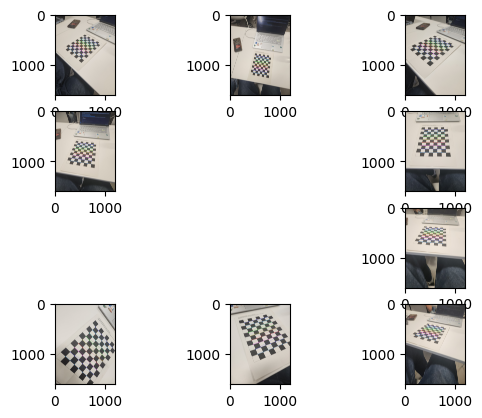

[output not shown]

```python
#plt.figure(figsize=figsize)
del_imgs=[]

for i, fn in enumerate(img_names):
    print("processing %s... " % fn)
    imgBGR = cv2.imread(fn)

    if imgBGR is None:
        print("Failed to load", fn)
        del_imgs.append(fn)
        continue

    imgRGB = cv2.cvtColor(imgBGR, cv2.COLOR_BGR2RGB)
    img = cv2.cvtColor(imgRGB, cv2.COLOR_RGB2GRAY)

    if h != img.shape[0] or w != img.shape[1]:
        print(f"Skipping {fn}: unexpected size {img.shape[1]} x {img.shape[0]}")
        del_imgs.append(fn)
        continue
    found, corners = cv2.findChessboardCorners(img, pattern_size)
    # # if you want to better improve the accuracy... cv2.findChessboardCorners already uses cv2.cornerSubPix
    # if found:
    #     term = (cv2.TERM_CRITERIA_EPS + cv2.TERM_CRITERIA_COUNT, 30, 0.1)
    #     cv2.cornerSubPix(img, corners, (5, 5), (-1, -1), term)

    if not found:
        print("chessboard not found")
        del_imgs.append(fn)
        continue

    if i < 12:
        img_w_corners = cv2.drawChessboardCorners(imgRGB, pattern_size, corners, found)
        plt.subplot(4, 3, i + 1)
        plt.imshow(img_w_corners)

    print(f"{fn}... OK")
    img_points.append(corners.reshape(-1, 2))
    obj_points.append(pattern_points)


plt.show()
print('Removed images: {}'.format(del_imgs))
for i, im in enumerate(del_imgs):
    img_names.remove(im)
#print(img_names)
```

```python
# calculate camera distortion
rms, camera_matrix, dist_coefs, _rvecs, _tvecs = cv2.calibrateCamera(obj_points, img_points, (w, h), None, None)

print("\nRMS:", rms)
print("camera matrix:\n", camera_matrix)
print("distortion coefficients: ", dist_coefs.ravel())
```

```
RMS: 1.685631593239024
camera matrix:
 [[1.09246946e+03 0.00000000e+00 6.03600800e+02]
 [0.00000000e+00 1.08806037e+03 8.00900728e+02]
 [0.00000000e+00 0.00000000e+00 1.00000000e+00]]
distortion coefficients:  [ 0.04113672  0.00110894  0.00230204 -0.00198074 -0.10341432]
```

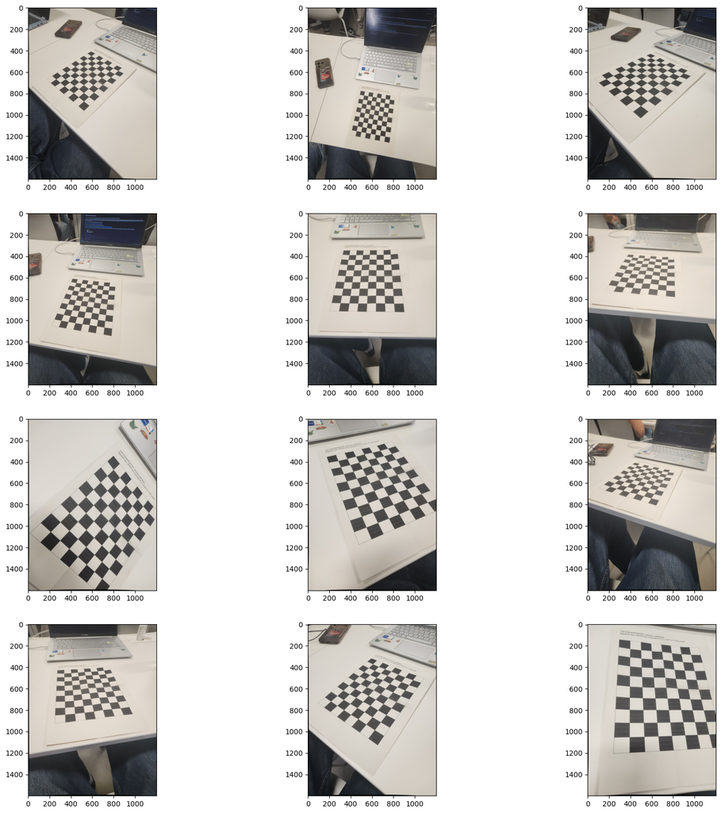

```
Done
```

```python
# undistort the image with the calibration
plt.figure(figsize=figsize)
for i, fn in enumerate(img_names):

    imgBGR = cv2.imread(fn)
    imgRGB = cv2.cvtColor(imgBGR, cv2.COLOR_BGR2RGB)

    dst = cv2.undistort(imgRGB, camera_matrix, dist_coefs)

    if i < 12:
        plt.subplot(4, 3, i + 1)
        plt.imshow(dst)

plt.show()
print("Done")
```

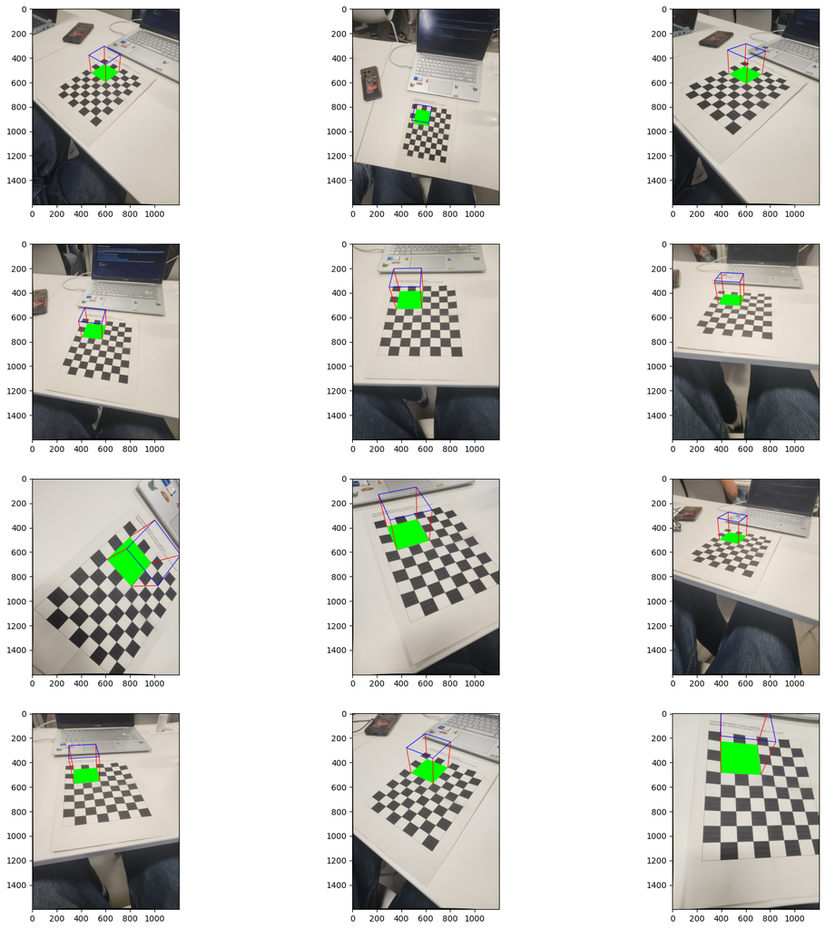

```python
objectPoints = (
    3
    * square_size
    * np.array([[0, 0, 0], [0, 1, 0], [1, 1, 0], [1, 0, 0], [0, 0, -1], [0, 1, -1], [1, 1, -1], [1, 0, -1]])
)


def draw(img, imgpts):
    imgpts = np.int32(imgpts).reshape(-1, 2)

    # draw ground floor in green
    img = cv2.drawContours(img, [imgpts[:4]], -1, (0, 255, 0), -1)

    # draw pillars in blue color
    for i, j in zip(range(4), range(4, 8)):
        img = cv2.line(img, tuple(imgpts[i]), tuple(imgpts[j]), (255), 3)

    # draw top layer in red color
    img = cv2.drawContours(img, [imgpts[4:]], -1, (0, 0, 255), 3)

    return img


plt.figure(figsize=figsize)
for i, fn in enumerate(img_names):

    imgBGR = cv2.imread(fn)
    imgRGB = cv2.cvtColor(imgBGR, cv2.COLOR_BGR2RGB)

    dst = cv2.undistort(imgRGB, camera_matrix, dist_coefs)

    imgpts = cv2.projectPoints(objectPoints, _rvecs[i], _tvecs[i], camera_matrix, dist_coefs)[0]
    drawn_image = draw(dst, imgpts)

    if i < 12:
        plt.subplot(4, 3, i + 1)
        plt.imshow(drawn_image)

plt.show()
```